# File Upload

David Gerard

2023-12-04

# Learning Objectives

- Learn how to upload datasets for use in the Shiny App.
- Chapter 8 of [Mastering Shiny](https://mastering-shiny.org/).
- [Shiny Cheatsheet](https://github.com/rstudio/cheatsheets/blob/master/shiny.pdf).
- Optional Resources
  - [Shiny Tutorial](https://stat545.com/shiny00_index.html).
  - [Shiny Examples](https://github.com/rstudio/shiny-examples).

# Static Dataset Upload

- If your Shiny app is designed to analyze only a single dataset (which might contain multiple files), then you should upload it at the start of the app.
  1. Create a new “data” folder in your app.
  2. Place all data files in the “data” folder.
  3. Read in these data at the start of the app.
- New data folder:

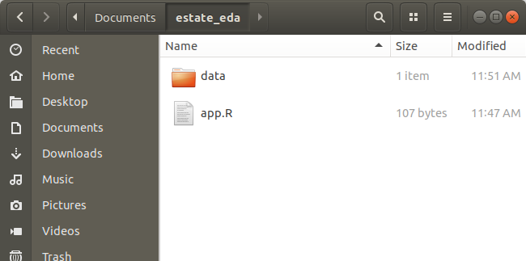

- Put data in data folder:

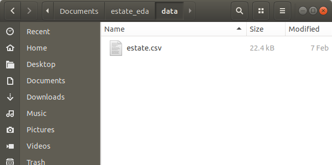

- Load data at beginning of app:

  ```r
  library(shiny)
  library(readr)
  estate <- read_csv("./data/estate.csv")

  ui <- fluidPage(
    tableOutput("estate")
  )

  server <- function(input, output, session) {
    output$estate <- renderTable({
      head(estate)
    })
  }

  shinyApp(ui, server)
  ```

- When a Shiny app is run, the location of “app.R” is the location of the working directory, so all file upload/download must be done from that location as a reference point.

# Interactive File Upload

- Use the `fileInput()` function in the UI to allow users to choose the source of the dataset.

  ```r
  library(shiny)

  ui <- fluidPage(
    fileInput("file", "Where is the file?")
  )

  server <- function(input, output, session) {

  }

  shinyApp(ui, server)
  ```

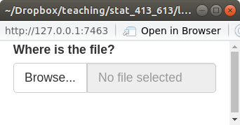

- In the `server()` function, the element in `input` (in this case `input$file`) is a data frame with the following columns:
  - `name`: The name of the file on the user’s computer.
  - `size`: The size of the file in bytes. Shiny only accepts files up to 5 MB. To increase it to 10 MB, type the following somewhere in “app.R”:

    ```r
    options(shiny.maxRequestSize = 10 * 1024^2)
    ```

  - `type`: The file extension (text/csv, text/plain etc)
  - `datapath`: A temporary path file.
- Useful arguments:
  - `accept`: What file extensions are acceptable (`".csv"`, `".txt"`, etc).
  - `buttonLabel`: Customize label of button.
  - `multiple`: Can the user upload multiple files?
- Example Shiny App

  ```r
  library(shiny)

  ui <- fluidPage(
    fileInput("upload", NULL, buttonLabel = "Upload...", multiple = TRUE),
    tableOutput("files")
  )

  server <- function(input, output, session) {
    output$files <- renderTable(input$upload)
  }

  shinyApp(ui = ui, server = server)
  ```

- General strategies:’
  - Place code to read in files inside a `reactive()` call.
  - Inside the reactive call, always use `req()` to wait to read in data until the path is available.
  - Save the read-in files as reactive elements.
  - In the server function, you use the `datapath` value as the `path` argument in `read_csv()`, `read_tsv()`, `readRDS()`, etc.

  ```r
  library(shiny)
  library(readr)

  ui <- fluidPage(
    fileInput("file", "What file?", accept = "text/csv"),
    tableOutput("head")
  )

  server <- function(input, output, session) {
    data <- reactive({
      req(input$file)
      read_csv(input$file$datapath)
    })

    output$head <- renderTable({
      head(data(), 5)
    })
  }

  shinyApp(ui, server)
  ```